# San Jose Federated City Employees Retirement Plan: preliminary results for discussion

$~$

# 1 **Updates**

## 1.1 Future updates

- Improve model calibration to better match the results in the actuarial valuation report
- Added risk analysis using stochastic simulations

$~$

# 2 **Overview**

## 2.1 Policy scenarios

We have modeled the San Jose Federated City Employees’ Retirement System under its current policy and under three types of alternative policies. The table below summarizes the key features of these polices.

Policy scenarios

|  | Benefit accrual | Max benefit | COLA | Employee contribution | POB |
| --- | --- | --- | --- | --- | --- |
| **Baseline (current policy)** | Tier1: 2.5% Tier2: 2% | 75%(Tier 1) or 70% (Tier 2) of final average salary | Tier1: 3% fixed Tier2: CPI capped at 1.25% ~ 2% depending on years of service | Tier1: 27.2% of normal cost Tier2: 50% ADC with limit on annual increase; no less than 50% of normal cost (city contribution no less than 50% of normal cost) |  |
| **Pre-1999 policy** | 3-year average for tier 1 |  | Tier1: 2.25% fixed Tier2: no change |  |  |
| **Cost sharing** |  |  | Suspend COLA before reaching full funding | Tier 2 shared-ADC policy applied to Tier 1 |  |
| **POB of full UAAL** |  |  |  |  | POB of full UAAL, 20 years with 3% interest; equal annual debt service |

1. **Pre-1999 policy:** Benefit provisions for new service are generally consistent with the policies before the major benefit changes around 1999.
   - Final average salary for tier 1 is calculated based on 3 years of salary
   - COLA for tier 1 is reduced from 3% to 2.25%.
   - We assume the reduction in future benefit is immediately reflected in the accrued liability and normal cost.
2. **Cost-sharing policy:**
   - The shared-ADC policy of Tier 2 is applied to Tier 1. Under the shared-ADC policy,
     - employee contribution is equal to 50% of the actuarially determined contribution (ADC)
     - the annual increase of employee contribution cannot be greater than 1/3 percent of payroll.
     - employee contribution cannot be less than 50% of the normal cost.
     - employer contribution cannot be less than 50% of the normal cost.
   - COLA is suspended until the plan reaches full funding, then COLA recovers to the baseline level.
3. **POB of full UAAL:**
   - The POB issuance is equal to the entire amount of UAAL in 2020.
   - Terms of POB: 20 years with 3% interest
   - Equal annual debt service

We assume all policies go fully into effect in the first year. The benefit factor reduction affects future service of current workers and all service of new hires. The COLA suspension affects all current retirees, all current workers, and all new hires.

## 2.2 Investment return scenarios

In the tables below we show results for 2020 (the actuarial valuation year and our first year) and for 2029. The model goes out much further in time and it can be useful to pay attention to later time periods as well to gain a better understanding of investment risks and amortization policies. We have examined these policies and variants under three investment scenarios:

1. Deterministic: 6.625% investment return assumption achieved every year. This is the San Jose police and fire plan assumption in 2020, save for any planned earnings assumption reductions.
2. Deterministic asset shock: This is based loosely on stress-test scenarios used by Pew, which in turn are based loosely on Dodd-Frank assumptions. We assume 6.625% return in 2020, 6.625% in 2021, negative 24% in 2022, then 3 years of 12% (2023-2025), then 6.625% annually thereafter.
3. Stochastic: 6.625% expected mean return, 12% standard deviation: This allows us to see how the policies, particularly the contingent COLA policy, interact with investment return volatility. The tables below provide summary results for the deterministic scenarios. We will add tables for the stochastic return scenario in a later iteration.

# 3 **Impact on contributions and funded status**

## 3.1 Summary

### Dollar values

Estimated impacts on contributions and UAAL of selected policy alternatives

$million

[output not shown]

<sup>*1*</sup> All existing amortization bases in 2020 are expected to be paid off by 2039; present values are calculated with a discount rate of 6.625%. <sup>*2*</sup> Including POB debt service <sup>*3*</sup> Including outstanding POB

### % difference from Baseline

Estimated impacts on contributions and UAAL of selected policy alternatives

Dollar amount ($million) for the baseline policy; % change from baseline amount under each alternative policy

[output not shown]

<sup>*1*</sup> All existing amortization bases in 2020 are expected to be paid off by 2039; present values are calculated with a discount rate of 6.625%. <sup>*2*</sup> Including POB debt service <sup>*3*</sup> Including outstanding POB

## 3.2 Deterministic results, with 6.625% annual returns

### Liability

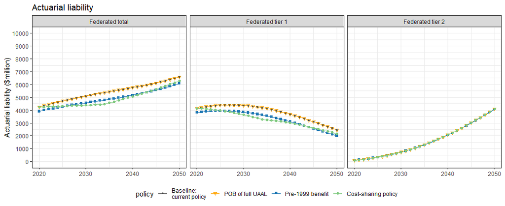

### Funded ratio (MVA)

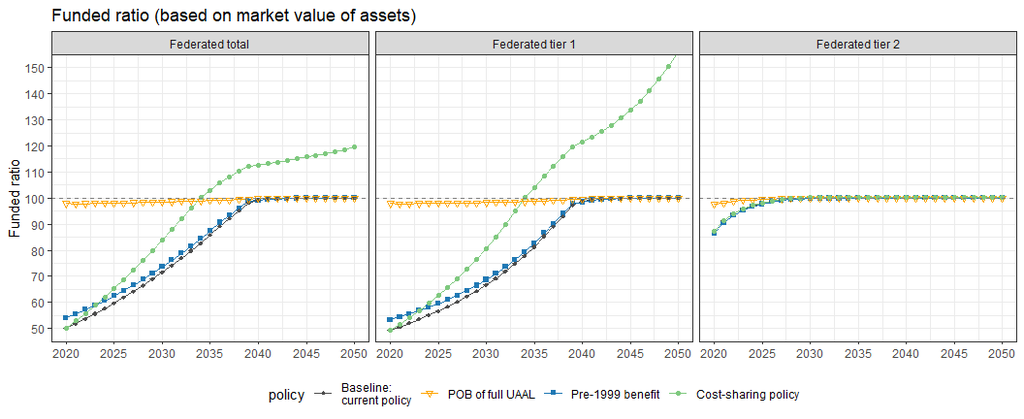

### Employer contribution rate

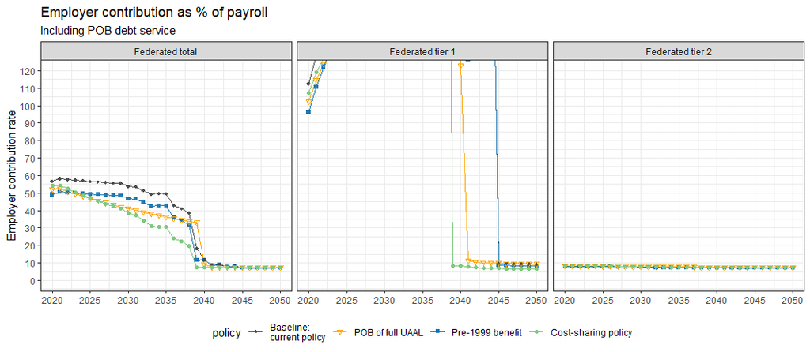

### Employee contribution rate

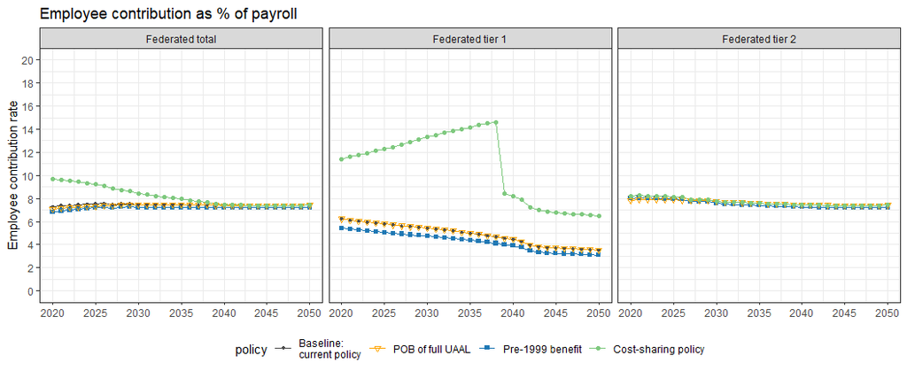

### Total normal cost rate

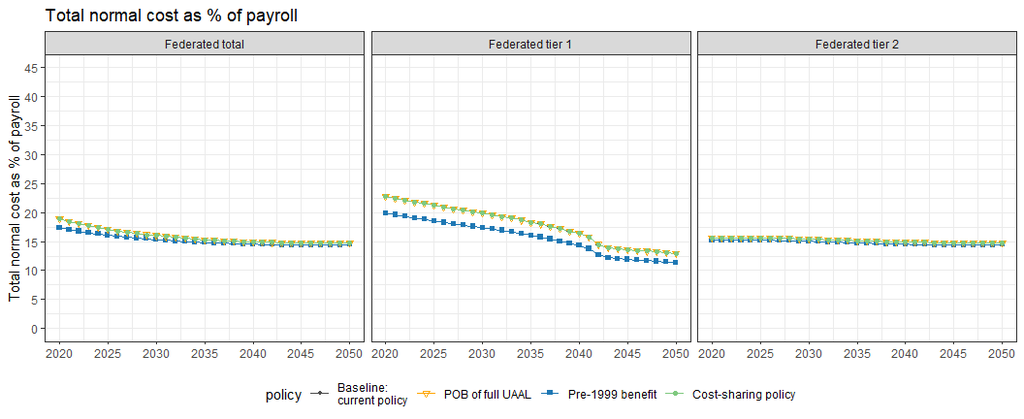

## 3.3 Asset shock scenario (24% decline in portfolio)

### Liability

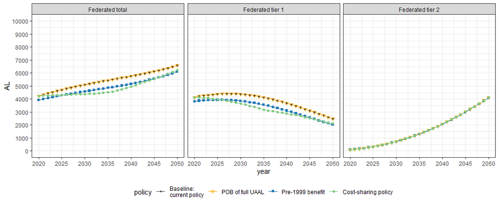

### Funded ratio (MVA)

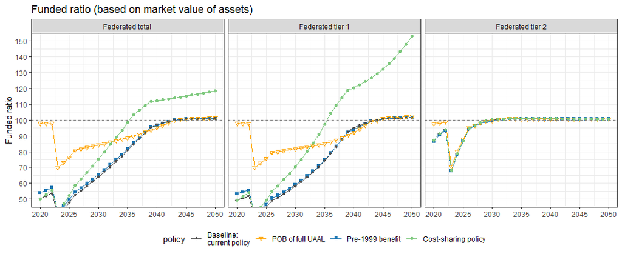

### Employer contribution rate

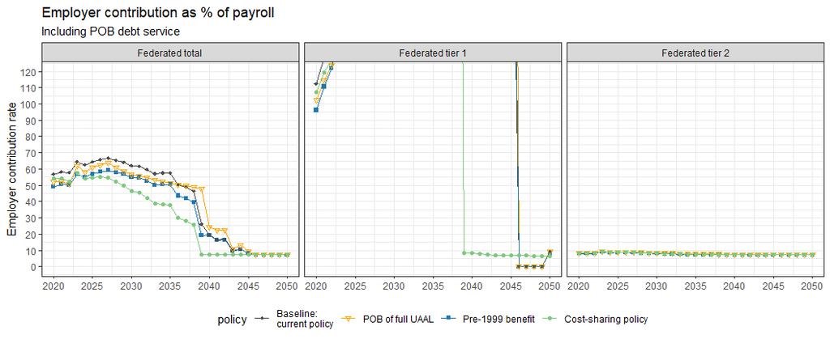

### Employee contribution rate

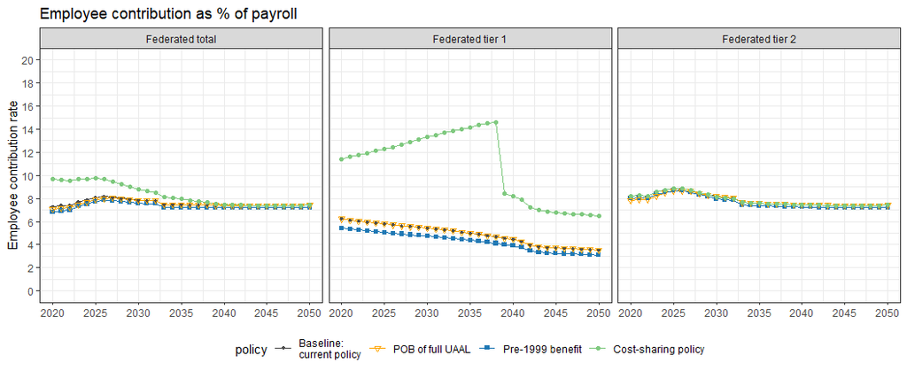

### Total normal cost rate

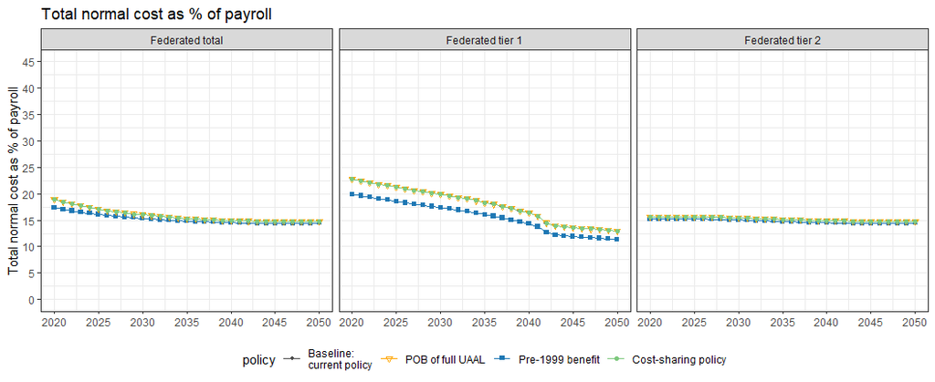

# 4 **Impact on member benefits**

Representative members to examine:

- Tier 1 service retiree at age 55 in 2021
- Late-career tier 1 active member at age 50 in 2021
- Mid-career tier 1 active member at age 35 in 2021
- Early-career tier 2 active member at age 25 in 2021

We assume all members above entered the plan at age 25 and retire at age 55 with 30 years of service.

## 4.1 Benefits

### Benefit at age 80

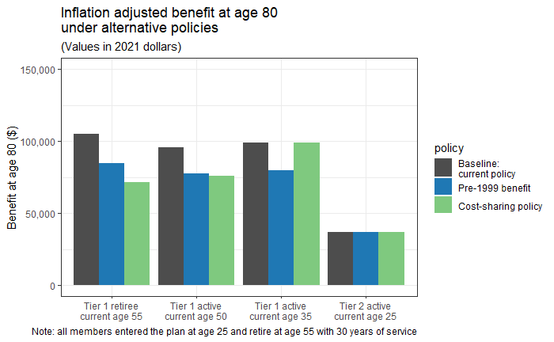

### Benefit at age 55

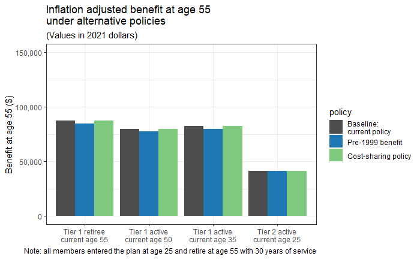

### Total benefit over age 55 to 85

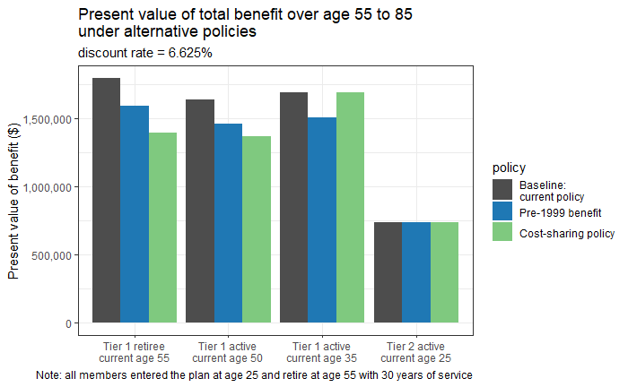

## 4.2 Employee contributions

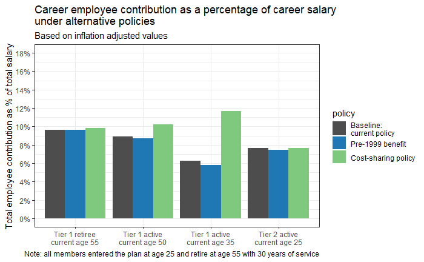